# 数据可视化

[figure not shown]

[figure not shown]

[figure not shown]

[figure not shown]

[figure not shown]

[figure not shown]

# 分向条形图

### 数据

通常遇到正负值，或者有一个固定对比值的时候，比如正负百分比变化，正负数值比较，我们可以做分向条形图（Diverging Bar） 比如我创造以下数据

```r
div_data <- data.frame(
  sample(-15:15, 10,
         replace=TRUE),
         c(1:10))
colnames(div_data) <- c('Value','Year')
head(div_data)
```

```
  Value Year
1    -5    1
2     0    2
3     9    3
4   -14    4
5    13    5
6    -3    6
```

那这种情况就可以做分向条形图做很直观的数值方向的对比

### 图表

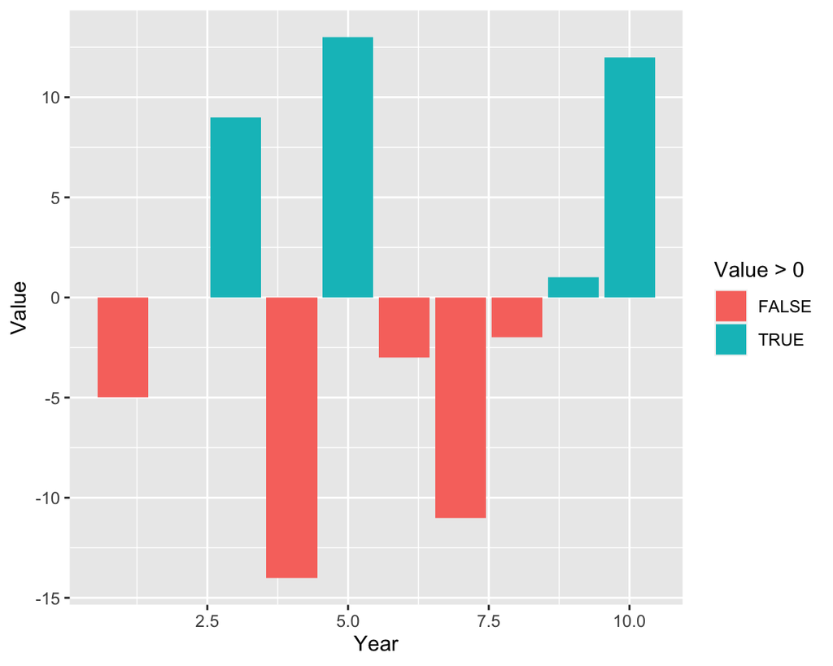

```r
ggplot(div_data, aes(x = Year, y = Value, fill = Value >0)) +
  geom_bar(stat = "identity")
```

# 分向堆叠条形图

### 数据

这里的数据是从[**Kaggle: Mark Kaghazgarian**](https://www.kaggle.com/marklvl/bike-sharing-dataset)获取的，它包含了华盛顿特区2011年以及2012年公共自行车的相关数据，里面有很多当地天气的信息。比如我想知道2011年当地四季的天气对比。 因为每个季节都有晴天(clear)，多云(cloudy)，小雨(light_drop)，大雨(heavy_drop)这样的天气，那我们可以用分向堆叠条形图展示。

```r
bike_ <- read.csv('~/R/test/day.csv')

bike_plot <- bike_[1:365, ] %>% group_by(season) %>%  summarise(
       clear = sum(weathersit==1),
        cloudy = sum(weathersit==2),
        light_drop = sum(weathersit==3),
        heacy_drop = sum(weathersit==4)
    )

bike_plot[1] <- c('Spring','Summer','Fall','Winter')
bike_plot$season <- as.factor(bike_plot$season)
bike_plot[,2:5] <- lapply(bike_plot[,2:5], as.numeric)

bike_plot
```

```
# A tibble: 4 × 5
  season clear cloudy light_drop heacy_drop
  <fct>  <dbl>  <dbl>      <dbl>      <dbl>
1 Spring    56     32          2          0
2 Summer    52     38          2          0
3 Fall      66     25          3          0
4 Winter    52     29          8          0
```

### 图表

这里用到的包是[**HH**](https://cran.r-project.org/web/packages/HH/index.html)

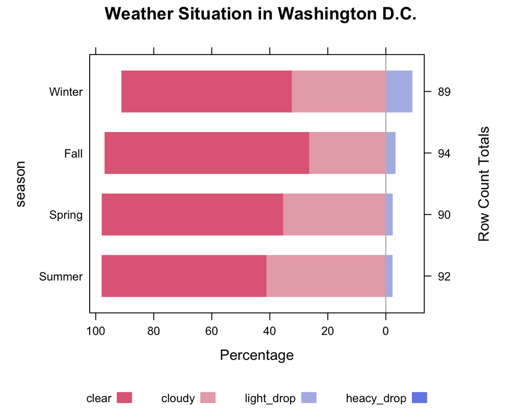

```r
likert(season ~ .,
       bike_plot,
       positive.order = TRUE,
       as.percent = TRUE,
       main = "Weather Situation in Washington D.C.", xlab = 'Percentage')
```

# 成对条形图

### 数据

这里的数据就直接调用自带的Titanic

当数据只有两个变量时，成对条形图可以做很好的对比

```r
(spine_data <- apply(Titanic, c(1,4), sum))
```

```
      Survived
Class   No Yes
  1st  122 203
  2nd  167 118
  3rd  528 178
  Crew 673 212
```

### 图表

R里面有自带的spineplot（）函数

Spine Plot还有另外一个优点就是，他还可以根据不同类别的占比调整柱的宽度

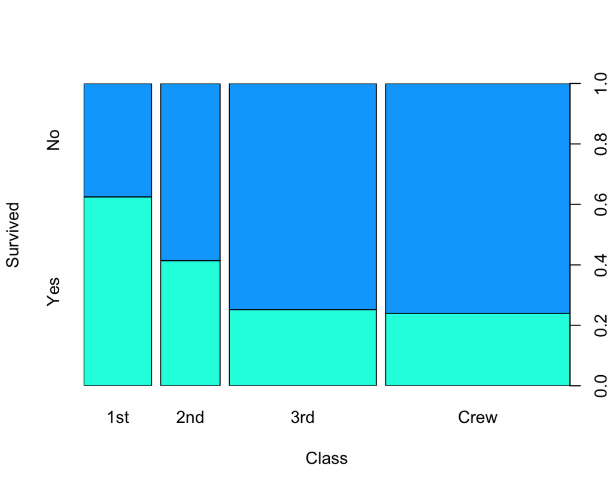

```r
spineplot(spine_data,
          col = c("#04FBE1", "#02A9FD")
          )
```

# 盈余/赤字填充线图

### 数据

```r
sur_def_table <- data.frame(seq(ymd('2021-01-01'),
                                ymd('2021-01-31'),
                                by = '1 day'),
                            c(runif(15, min = -1.8, max = -0.2),
                              runif(16, min = 0.5, max = 5))
                            )
colnames(sur_def_table) <- c('Date', 'Value')

head(sur_def_table)
```

```
        Date      Value
1 2021-01-01 -0.9514110
2 2021-01-02 -0.5389231
3 2021-01-03 -0.8736823
4 2021-01-04 -0.4553608
5 2021-01-05 -1.2674464
6 2021-01-06 -0.5366704
```

### 图表

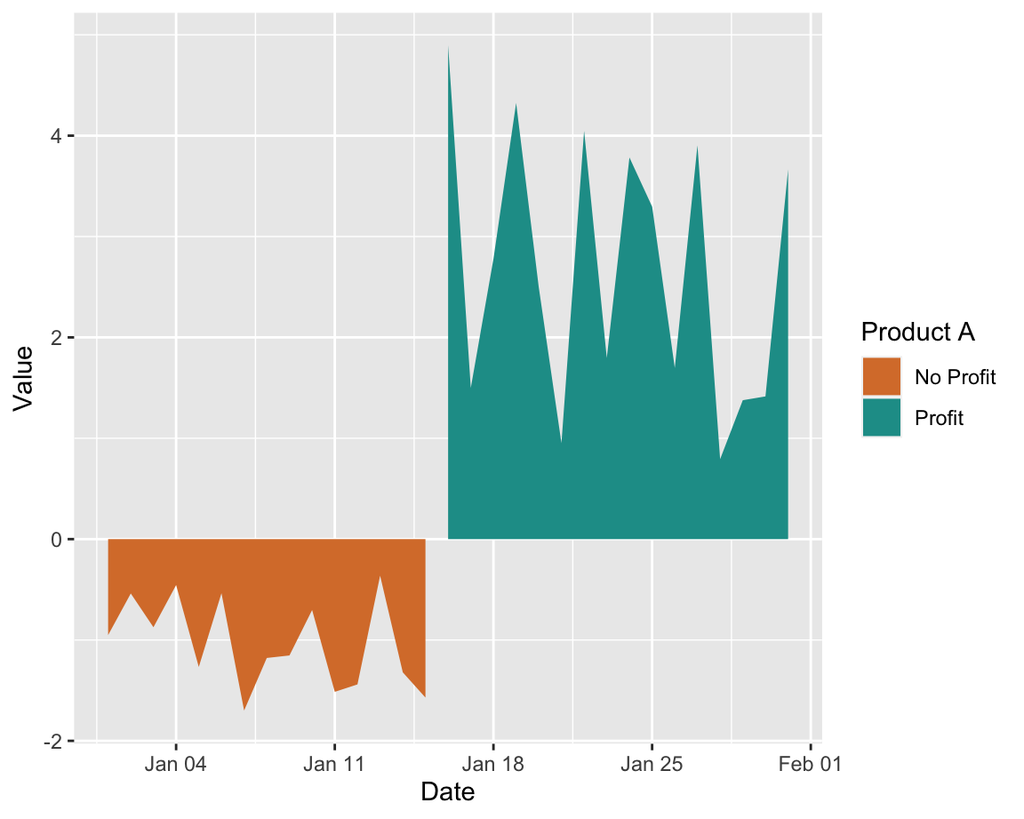

```r
ggplot(sur_def_table,
       aes(x = Date, y = Value, fill = Value > 0)) +
  geom_area() +
  scale_fill_manual(name = 'Product A',
                    values = c('#d97d36','#1c9c97'),
                    labels = c('No Profit','Profit'))
```